# PCA

August 26, 2016

## Dados

Resolvi então usar o PCA nas seguintes Areas: Assitência Social, Saúde , Saneamento.

```r
emendas <- read.csv("emendas_area_parlamentar.csv")
emendas <-subset(emendas, !is.na(NOME_PARLAMENTAR))
emendas2 <- log(emendas[,2:18]+1)
emendas2$NOME_PARLAMENTAR <- emendas$NOME_PARLAMENTAR
emendas3 <- emendas2[c(13, 14, 2)]
row.names(emendas3) = emendas2$NOME_PARLAMENTAR
pr.out = prcomp(emendas3, scale = TRUE)
kable(pr.out$rotation)
```

|  | PC1 | PC2 | PC3 |
| --- | --- | --- | --- |
| Saneamento | 0.6186742 | -0.0096125 | 0.7855888 |
| Saude | 0.5568650 | -0.6999940 | -0.4471127 |
| Assistencia.Social | 0.5542053 | 0.7140840 | -0.4277154 |

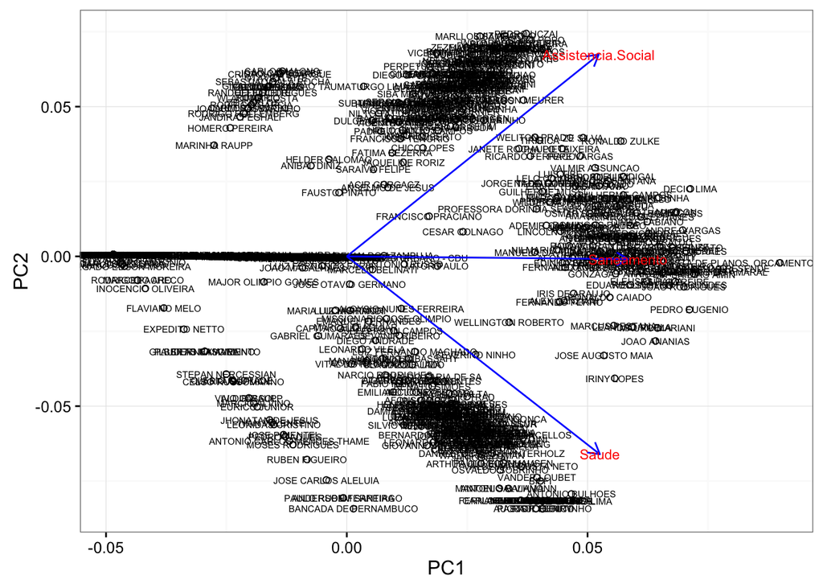

```r
autoplot(pr.out, label = TRUE, label.size = 2, shape = TRUE,
         loadings = TRUE, loadings.colour = 'blue',
         loadings.label = TRUE, loadings.label.size = 3)
```

Utilizando o PCA, é possível observar que os vetores todos tendem a direita, mas variam em relação ao eixo y. Nos indicando que as nuvens de deputados localizadas há direita tiveram emendas em uma das 3 aéreas, quanto mais a direita, mais investido em saneamento, os de baixo investiram mais em Saúde e os de cima me Assistência Social. Ja os a esquedas sobre o eixo x investem em outras áreas.

Se quisermos ver os deputados que vai investem em saúde devemos ver quais deputados estão na nuvem inferior. Ex. Oswaldo Sobrinho.

## Porcentagem de Variância Explicada

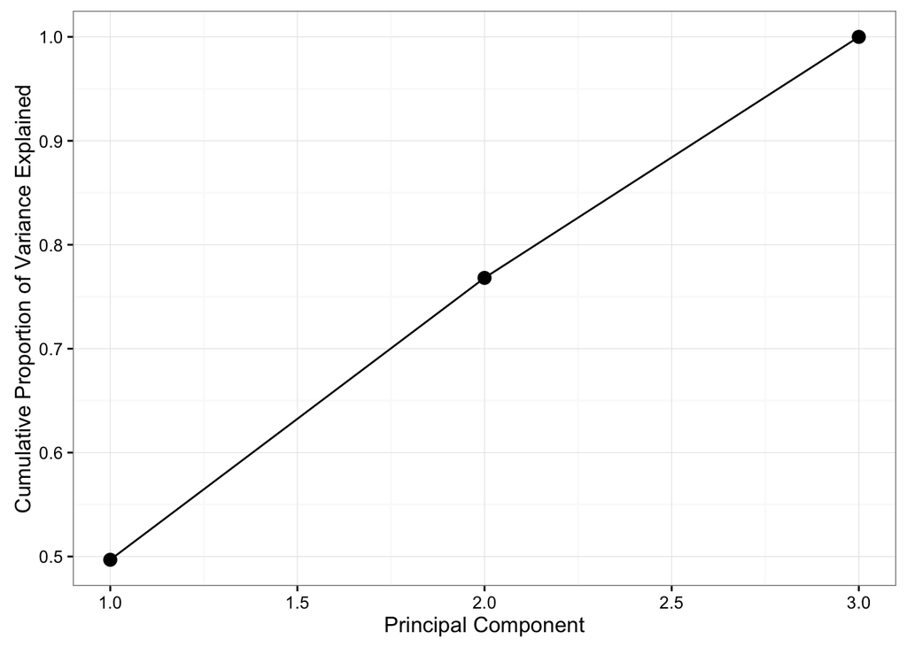

```r
plot_pve <- function(prout){
  pr.var <- pr.out$sdev^2
  pve <- pr.var / sum(pr.var)
  df = data.frame(x = 1:NROW(pve), y = cumsum(pve))
  ggplot(df, aes(x = x, y = y)) +
    geom_point(size = 3) +
    geom_line() +
    labs(x='Principal Component', y = 'Cumulative Proportion of Variance Explained')
}

plot_pve(pr.out)
```

O gráfico indica quanto da variância original estamos conseguindo reproduzir com menos variáveis. Com duas variáveis conseguimos representar pouco menos de 80% da variância original.

## t-SNE

```r
library(Rtsne)
tsne.out = Rtsne(log(emendas3 + 1),
                 verbose = TRUE, check_duplicates=FALSE)
```

[output not shown]

```r
df = as.data.frame(tsne.out$Y)
df$NOME_PARLAMENTAR = emendas2$NOME_PARLAMENTAR

myPlot <- plot_ly(df, x = V1, y = V2, text = paste("Parlamentar: ", NOME_PARLAMENTAR), name = "nome", mode = "markers") %>%
  layout(
      title = "t-SNE",
      xaxis = list(title = "V1"),
      yaxis = list(title = "V2"),
      margin = list(l = 65)
    )

myPlot
```

[interactive chart not shown]

Já sobre a visualização do t-SNE, observamos grupos mais bem formados e distintos entre si. Com isso é mais fácil notar parlamentares com emendas em áreas semelhantes e proximidades entre grupos. Nesse grupo de dados tivemos quatro grupos em forma de cluster ficando em direções opostas e apenas um grupo como uma listra, e alguns poucos pontos avulsos.